# R -MidTerm Project

Third Team

2023-12-09

# 1 Explarotary Data Analysis

## 1.1 Loading the Data

```r
customer_data=read.csv((file.choose()))
# Convert date to a proper date format
customer_data$invoice_date = as.Date(customer_data$invoice_date, format = "%d/%m/%Y")
head(customer_data)
```

```
##   invoice_no customer_id gender age category quantity  price payment_method
## 1    I138884     C241288 Female  28 Clothing        5 1500.4    Credit Card
## 2    I317333     C111565   Male  21    Shoes        3 1800.5     Debit Card
## 3    I127801     C266599   Male  20 Clothing        1  300.1           Cash
## 4    I173702     C988172 Female  66    Shoes        5 3000.8    Credit Card
## 5    I337046     C189076 Female  53    Books        4   60.6           Cash
## 6    I227836     C657758 Female  28 Clothing        5 1500.4    Credit Card
##   invoice_date  shopping_mall
## 1   2022-08-05         Kanyon
## 2   2021-12-12 Forum Istanbul
## 3   2021-11-09      Metrocity
## 4   2021-05-16   Metropol AVM
## 5   2021-10-24         Kanyon
## 6   2022-05-24 Forum Istanbul
```

After the conversion of correct Date Time formate.

## 1.2 Defining the Target Variable

```r
customer_data$total_cost <- customer_data$quantity * customer_data$price

head(customer_data)
```

```
##   invoice_no customer_id gender age category quantity  price payment_method
## 1    I138884     C241288 Female  28 Clothing        5 1500.4    Credit Card
## 2    I317333     C111565   Male  21    Shoes        3 1800.5     Debit Card
## 3    I127801     C266599   Male  20 Clothing        1  300.1           Cash
## 4    I173702     C988172 Female  66    Shoes        5 3000.8    Credit Card
## 5    I337046     C189076 Female  53    Books        4   60.6           Cash
## 6    I227836     C657758 Female  28 Clothing        5 1500.4    Credit Card
##   invoice_date  shopping_mall total_cost
## 1   2022-08-05         Kanyon       7502
## 2   2021-12-12 Forum Istanbul       5402
## 3   2021-11-09      Metrocity        300
## 4   2021-05-16   Metropol AVM      15004
## 5   2021-10-24         Kanyon        242
## 6   2022-05-24 Forum Istanbul       7502
```

Target Variable is the Product of two individual Features in the given Columns of the DataSet.

## 1.3 Verifying the Null Values and Data Claeaning

```r
# Check for missing values
sum(is.na(customer_data))
```

```
## [1] 0
```

```r
# Check data types
str(customer_data)
```

```
## 'data.frame':    99457 obs. of  11 variables:
##  $ invoice_no    : chr  "I138884" "I317333" "I127801" "I173702" ...
##  $ customer_id   : chr  "C241288" "C111565" "C266599" "C988172" ...
##  $ gender        : chr  "Female" "Male" "Male" "Female" ...
##  $ age           : int  28 21 20 66 53 28 49 32 69 60 ...
##  $ category      : chr  "Clothing" "Shoes" "Clothing" "Shoes" ...
##  $ quantity      : int  5 3 1 5 4 5 1 2 3 2 ...
##  $ price         : num  1500.4 1800.5 300.1 3000.8 60.6 ...
##  $ payment_method: chr  "Credit Card" "Debit Card" "Cash" "Credit Card" ...
##  $ invoice_date  : Date, format: "2022-08-05" "2021-12-12" ...
##  $ shopping_mall : chr  "Kanyon" "Forum Istanbul" "Metrocity" "Metropol AVM" ...
##  $ total_cost    : num  7502 5402 300 15004 242 ...
```

For Checking the Data Types of the choosen DataSet

## 1.4 Ensure proper factors

```r
customer_data$gender = factor(customer_data$gender)
customer_data$category = factor(customer_data$category)
customer_data$payment_method = factor(customer_data$payment_method)
customer_data$shopping_mall = factor(customer_data$shopping_mall)
```

It is used to store categorical variables along with that which takes the categorical variable and stores data in levels as we defined

## 1.5 Check the dataset For Analysis

```r
head(customer_data)
```

```
##   invoice_no customer_id gender age category quantity  price payment_method
## 1    I138884     C241288 Female  28 Clothing        5 1500.4    Credit Card
## 2    I317333     C111565   Male  21    Shoes        3 1800.5     Debit Card
## 3    I127801     C266599   Male  20 Clothing        1  300.1           Cash
## 4    I173702     C988172 Female  66    Shoes        5 3000.8    Credit Card
## 5    I337046     C189076 Female  53    Books        4   60.6           Cash
## 6    I227836     C657758 Female  28 Clothing        5 1500.4    Credit Card
##   invoice_date  shopping_mall total_cost
## 1   2022-08-05         Kanyon       7502
## 2   2021-12-12 Forum Istanbul       5402
## 3   2021-11-09      Metrocity        300
## 4   2021-05-16   Metropol AVM      15004
## 5   2021-10-24         Kanyon        242
## 6   2022-05-24 Forum Istanbul       7502
```

```r
#summary(customer_data)
```

## 1.6 Subsetting the dataset based on different conditions

```r
# Subsetting the dataset for female customers
female_customers = subset(customer_data, gender == "Female")
head(female_customers)
```

```
##   invoice_no customer_id gender age  category quantity  price payment_method
## 1    I138884     C241288 Female  28  Clothing        5 1500.4    Credit Card
## 4    I173702     C988172 Female  66     Shoes        5 3000.8    Credit Card
## 5    I337046     C189076 Female  53     Books        4   60.6           Cash
## 6    I227836     C657758 Female  28  Clothing        5 1500.4    Credit Card
## 7    I121056     C151197 Female  49 Cosmetics        1   40.7           Cash
## 8    I293112     C176086 Female  32  Clothing        2  600.2    Credit Card
##   invoice_date    shopping_mall total_cost
## 1   2022-08-05           Kanyon     7502.0
## 4   2021-05-16     Metropol AVM    15004.2
## 5   2021-10-24           Kanyon      242.4
## 6   2022-05-24   Forum Istanbul     7502.0
## 7   2022-03-13     Istinye Park       40.7
## 8   2021-01-13 Mall of Istanbul     1200.3
```

```r
# Subsetting the dataset for customers older than 30
older_customers = subset(customer_data, age > 30)
head(older_customers)
```

```
##    invoice_no customer_id gender age  category quantity  price payment_method
## 4     I173702     C988172 Female  66     Shoes        5 3000.8    Credit Card
## 5     I337046     C189076 Female  53     Books        4   60.6           Cash
## 7     I121056     C151197 Female  49 Cosmetics        1   40.7           Cash
## 8     I293112     C176086 Female  32  Clothing        2  600.2    Credit Card
## 9     I293455     C159642   Male  69  Clothing        3  900.2    Credit Card
## 10    I326945     C283361 Female  60  Clothing        2  600.2    Credit Card
##    invoice_date    shopping_mall total_cost
## 4    2021-05-16     Metropol AVM    15004.2
## 5    2021-10-24           Kanyon      242.4
## 7    2022-03-13     Istinye Park       40.7
## 8    2021-01-13 Mall of Istanbul     1200.3
## 9    2021-11-04        Metrocity     2700.7
## 10   2021-08-22           Kanyon     1200.3
```

```r
# Subsetting the dataset for Clothing category
clothing_data = subset(customer_data, category == "Clothing")
head(clothing_data)
```

```
##    invoice_no customer_id gender age category quantity price payment_method
## 1     I138884     C241288 Female  28 Clothing        5  1500    Credit Card
## 3     I127801     C266599   Male  20 Clothing        1   300           Cash
## 6     I227836     C657758 Female  28 Clothing        5  1500    Credit Card
## 8     I293112     C176086 Female  32 Clothing        2   600    Credit Card
## 9     I293455     C159642   Male  69 Clothing        3   900    Credit Card
## 10    I326945     C283361 Female  60 Clothing        2   600    Credit Card
##    invoice_date    shopping_mall total_cost
## 1    2022-08-05           Kanyon       7502
## 3    2021-11-09        Metrocity        300
## 6    2022-05-24   Forum Istanbul       7502
## 8    2021-01-13 Mall of Istanbul       1200
## 9    2021-11-04        Metrocity       2701
## 10   2021-08-22           Kanyon       1200
```

```r
# Subsetting the dataset for customers who shopped at Kanyon mall
kanyon_shoppers = subset(customer_data, shopping_mall == "Kanyon")
head(kanyon_shoppers)
```

```
##    invoice_no customer_id gender age   category quantity  price payment_method
## 1     I138884     C241288 Female  28   Clothing        5 1500.4    Credit Card
## 5     I337046     C189076 Female  53      Books        4   60.6           Cash
## 10    I326945     C283361 Female  60   Clothing        2  600.2    Credit Card
## 15    I336189     C555402 Female  67   Clothing        2  600.2    Credit Card
## 24    I252275     C313348   Male  44 Technology        5 5250.0           Cash
## 33    I768348     C176727 Female  32      Shoes        3 1800.5    Credit Card
##    invoice_date shopping_mall total_cost
## 1    2022-08-05        Kanyon       7502
## 5    2021-10-24        Kanyon        242
## 10   2021-08-22        Kanyon       1200
## 15   2022-06-03        Kanyon       1200
## 24   2021-10-26        Kanyon      26250
## 33   2022-02-23        Kanyon       5402
```

```r
# Subsetting the dataset for customers who used Credit Card as the payment method
credit_card_customers = subset(customer_data, payment_method == "Credit Card")
head(credit_card_customers)
```

```
##    invoice_no customer_id gender age category quantity price payment_method
## 1     I138884     C241288 Female  28 Clothing        5  1500    Credit Card
## 4     I173702     C988172 Female  66    Shoes        5  3001    Credit Card
## 6     I227836     C657758 Female  28 Clothing        5  1500    Credit Card
## 8     I293112     C176086 Female  32 Clothing        2   600    Credit Card
## 9     I293455     C159642   Male  69 Clothing        3   900    Credit Card
## 10    I326945     C283361 Female  60 Clothing        2   600    Credit Card
##    invoice_date    shopping_mall total_cost
## 1    2022-08-05           Kanyon       7502
## 4    2021-05-16     Metropol AVM      15004
## 6    2022-05-24   Forum Istanbul       7502
## 8    2021-01-13 Mall of Istanbul       1200
## 9    2021-11-04        Metrocity       2701
## 10   2021-08-22           Kanyon       1200
```

The code creates subsets depending on a variety of parameters, including gender, age, product category, shopping mall, and payment method, in an effort to explore and comprehend diverse regions of the dataset. It creates unique subsets of data for additional analysis by using the’subset’ function to filter the dataset rows that satisfy each requirement. The initial few rows of each subset are then shown using the ‘head’ function, giving a sneak peek at the data that meets each specific requirement. This code enables for a more specific and concentrated investigation of the various dataset parts and forms the basis for data exploration. # 2 Data Visuvalization

## 2.1 Plotting the Distribution Graphs

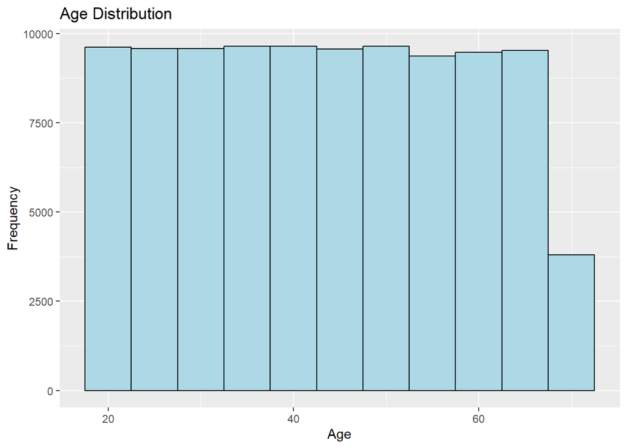

```r
# Histogram for Age
library(ggplot2)
ggplot(customer_data, aes(x = age)) +
  geom_histogram(binwidth = 5, fill = "lightblue", color = "black") +
  labs(
    title = "Age Distribution",
    x = "Age",
    y = "Frequency"
  )
```

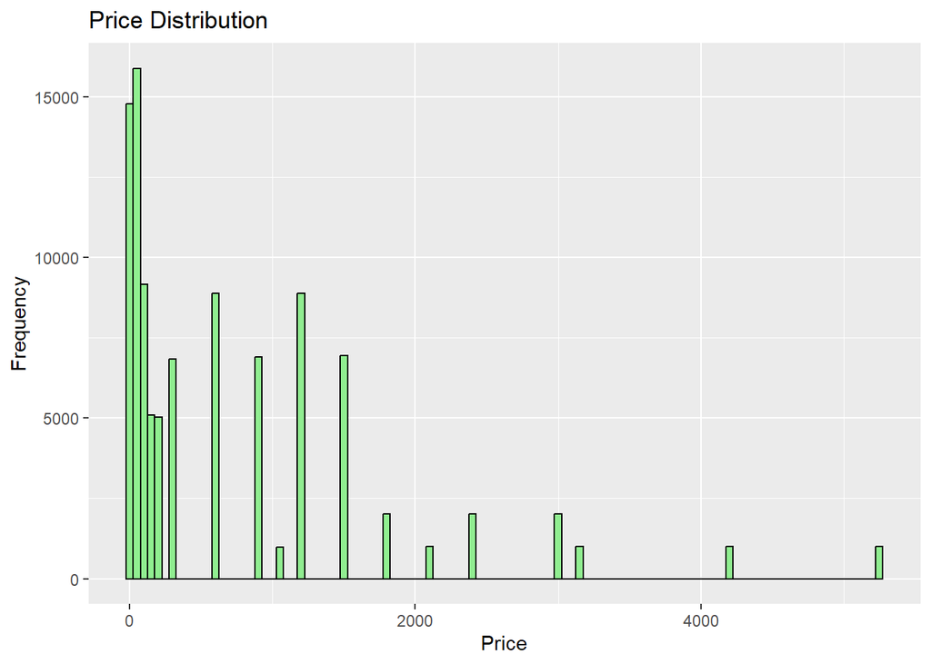

```r
# Histogram for Price
ggplot(customer_data, aes(x = price)) +
  geom_histogram(binwidth = 50, fill = "lightgreen", color = "black") +
  labs(
    title = "Price Distribution",
    x = "Price",
    y = "Frequency"
  )
```

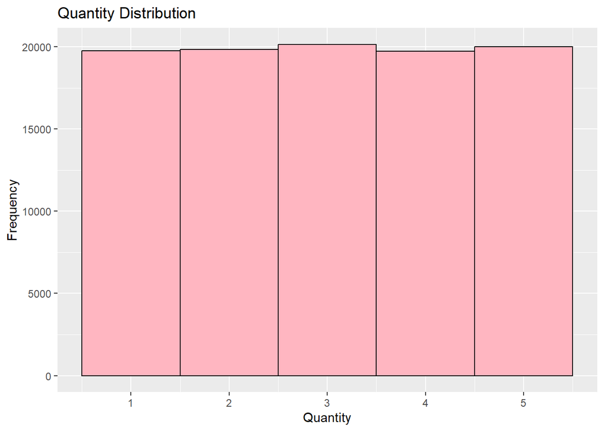

```r
# Histogram for Quantity
ggplot(customer_data, aes(x = quantity)) +
  geom_histogram(binwidth = 1, fill = "lightpink", color = "black") +
  labs(
    title = "Quantity Distribution",
    x = "Quantity",
    y = "Frequency"
  )
```

## 2.2 Plotting the Feature vs.Feature Graph comparision

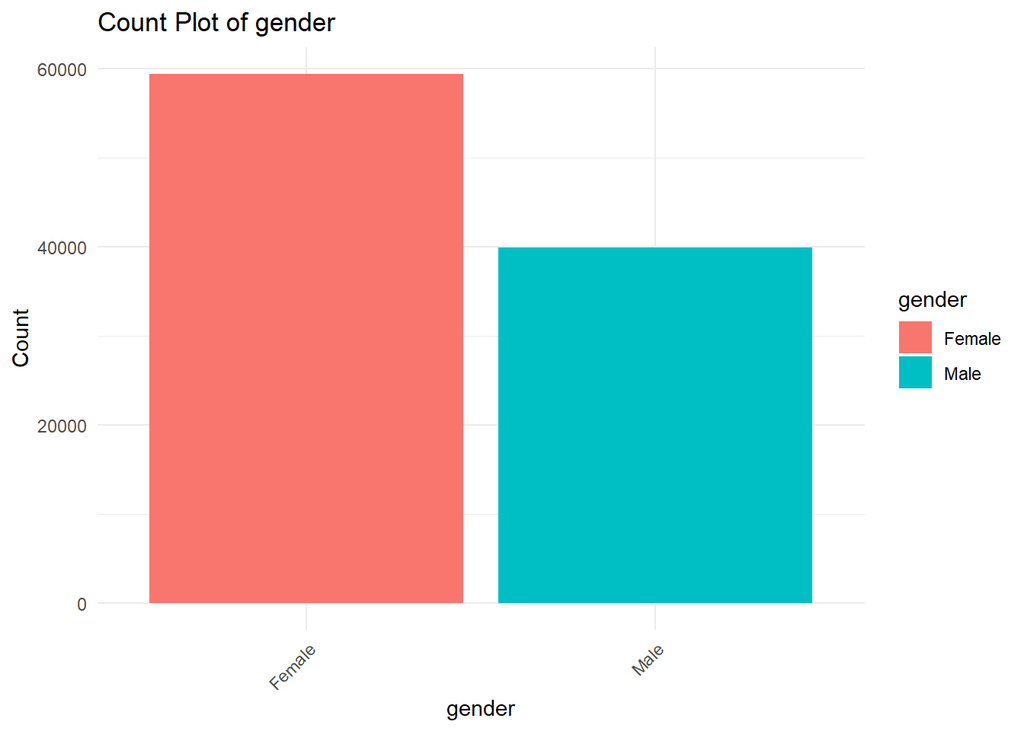

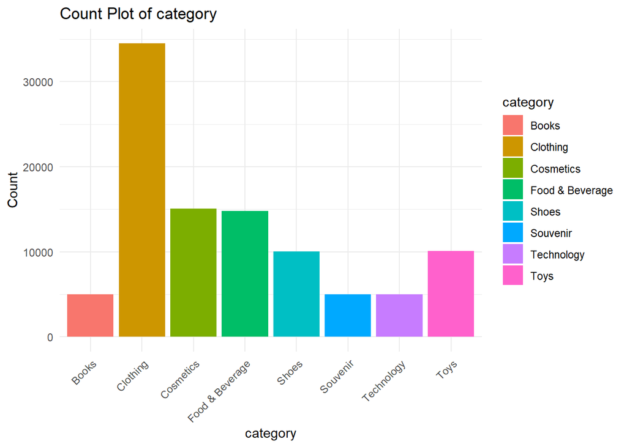

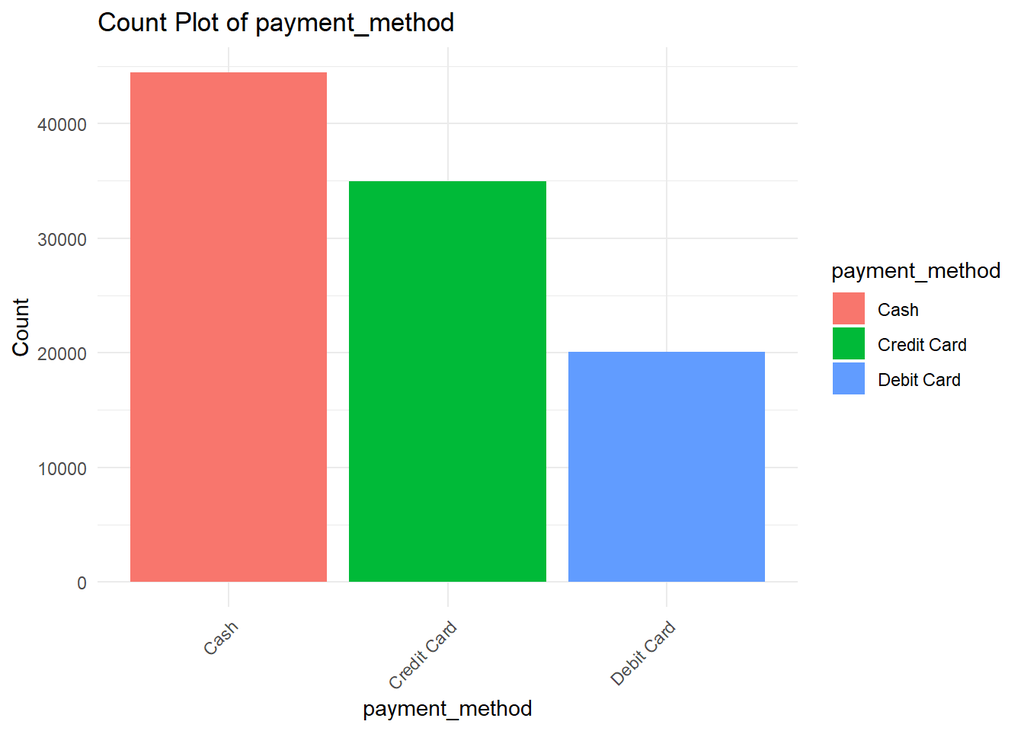

```r
# Load the ggplot2 library if not already loaded
library(ggplot2)

# Create a list of categorical features to visualize
categorical_features <- c("gender", "category", "payment_method")

# Create a plot for each categorical feature
for (feature in categorical_features) {
  # Create a count plot for the current feature
  plot <- ggplot(customer_data, aes_string(x = feature, fill = feature)) +
    geom_bar() +
    labs(
      title = paste("Count Plot of", feature),
      x = feature,
      y = "Count"
    ) +
    theme_minimal() +
    theme(axis.text.x = element_text(angle = 45, hjust = 1))

  # Display the plot
  print(plot)
}
```

## 2.3 Bar plot for the catogiry and the count of values

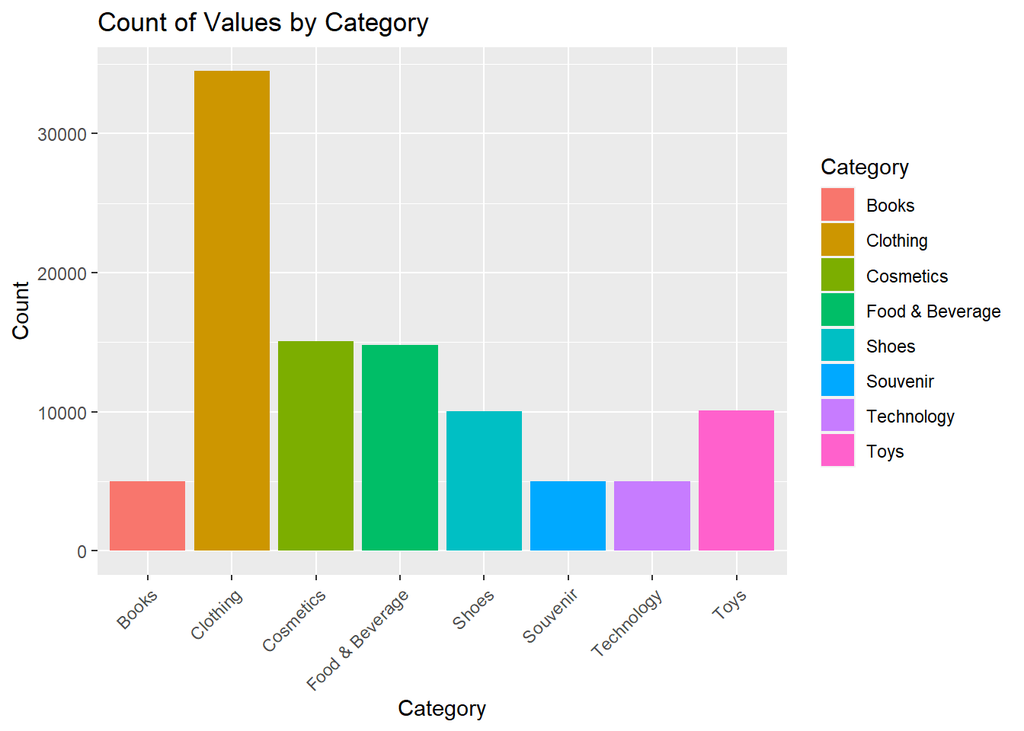

```r
library(ggplot2)

# Count the occurrences of each category
category_counts <- table(customer_data$category)

# Create a data frame from the counts
category_df <- data.frame(Category = names(category_counts), Count = as.numeric(category_counts))

# Create the barplot
ggplot(category_df, aes(x = Category, y = Count, fill = Category)) +
  geom_bar(stat = "identity") +
  labs(
    title = "Count of Values by Category",
    x = "Category",
    y = "Count"
  ) +
  theme(axis.text.x = element_text(angle = 45, hjust = 1))  # Rotate x-axis labels for better readability
```

# 3 Feature Engineering

## 3.1 Rechange the columns Feature engineering – One hot Encoding

```r
# Perform one-hot encoding for payment method
payment_methods <- unique(customer_data$payment_method)
for (method in payment_methods) {
  customer_data[paste0("payment_", method)] <- as.integer(customer_data$payment_method == method)
}
head(customer_data)
```

```
##   invoice_no customer_id gender age category quantity  price payment_method
## 1    I138884     C241288 Female  28 Clothing        5 1500.4    Credit Card
## 2    I317333     C111565   Male  21    Shoes        3 1800.5     Debit Card
## 3    I127801     C266599   Male  20 Clothing        1  300.1           Cash
## 4    I173702     C988172 Female  66    Shoes        5 3000.8    Credit Card
## 5    I337046     C189076 Female  53    Books        4   60.6           Cash
## 6    I227836     C657758 Female  28 Clothing        5 1500.4    Credit Card
##   invoice_date  shopping_mall total_cost payment_Credit Card payment_Debit Card
## 1   2022-08-05         Kanyon       7502                   1                  0
## 2   2021-12-12 Forum Istanbul       5402                   0                  1
## 3   2021-11-09      Metrocity        300                   0                  0
## 4   2021-05-16   Metropol AVM      15004                   1                  0
## 5   2021-10-24         Kanyon        242                   0                  0
## 6   2022-05-24 Forum Istanbul       7502                   1                  0
##   payment_Cash
## 1            0
## 2            0
## 3            1
## 4            0
## 5            1
## 6            0
```

```r
genders <- unique(customer_data$gender)
for (method in genders) {
  customer_data[paste0("gender_", method)] <- as.integer(customer_data$gender == method)
}
head(customer_data)
```

```
##   invoice_no customer_id gender age category quantity  price payment_method
## 1    I138884     C241288 Female  28 Clothing        5 1500.4    Credit Card
## 2    I317333     C111565   Male  21    Shoes        3 1800.5     Debit Card
## 3    I127801     C266599   Male  20 Clothing        1  300.1           Cash
## 4    I173702     C988172 Female  66    Shoes        5 3000.8    Credit Card
## 5    I337046     C189076 Female  53    Books        4   60.6           Cash
## 6    I227836     C657758 Female  28 Clothing        5 1500.4    Credit Card
##   invoice_date  shopping_mall total_cost payment_Credit Card payment_Debit Card
## 1   2022-08-05         Kanyon       7502                   1                  0
## 2   2021-12-12 Forum Istanbul       5402                   0                  1
## 3   2021-11-09      Metrocity        300                   0                  0
## 4   2021-05-16   Metropol AVM      15004                   1                  0
## 5   2021-10-24         Kanyon        242                   0                  0
## 6   2022-05-24 Forum Istanbul       7502                   1                  0
##   payment_Cash gender_Female gender_Male
## 1            0             1           0
## 2            0             0           1
## 3            1             0           1
## 4            0             1           0
## 5            1             1           0
## 6            0             1           0
```

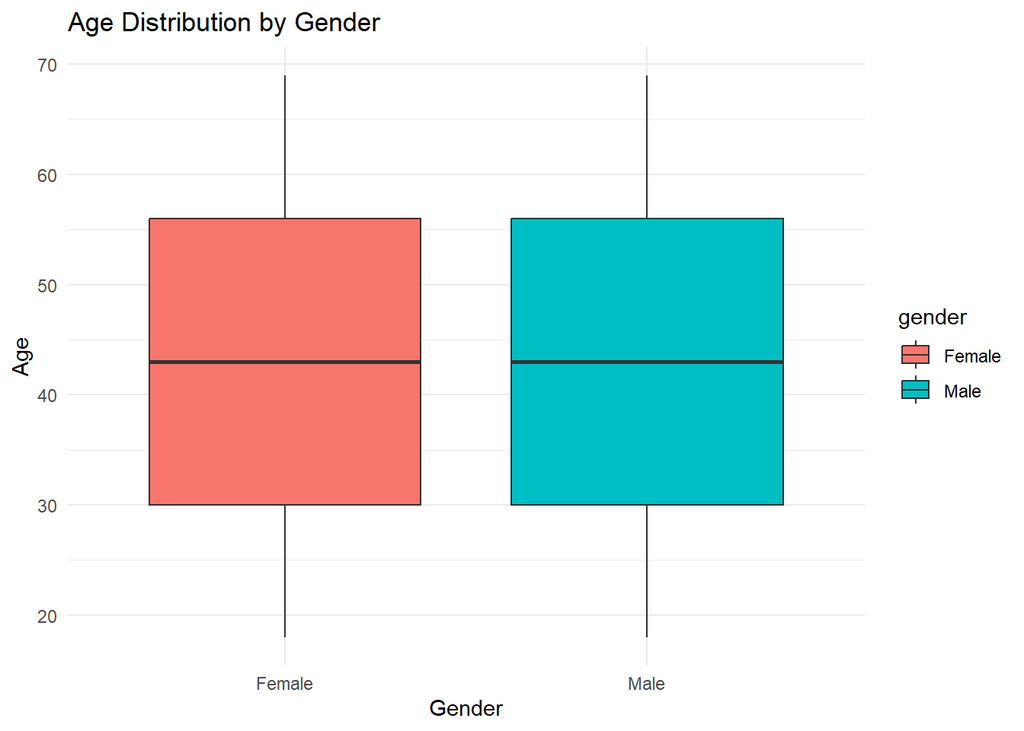

```r
# Load the necessary libraries (ggplot2)
library(ggplot2)

# Create a box plot for age distribution by gender
ggplot(customer_data, aes(x = gender, y = age, fill = gender)) +
  geom_boxplot() +
  labs(
    title = "Age Distribution by Gender",
    x = "Gender",
    y = "Age"
  ) +
  theme_minimal()
```

```r
# Summary
summary_gender_age = summary(customer_data$gender)
summary_age = summary(customer_data$age)
```

```r
colnames(customer_data)
```

```
##  [1] "invoice_no"          "customer_id"         "gender"
##  [4] "age"                 "category"            "quantity"
##  [7] "price"               "payment_method"      "invoice_date"
## [10] "shopping_mall"       "total_cost"          "payment_Credit Card"
## [13] "payment_Debit Card"  "payment_Cash"        "gender_Female"
## [16] "gender_Male"
```

# 4 Corelation Matrix After Feature Engineering

## 4.1 Calculating the correlation matrix for numerical variables

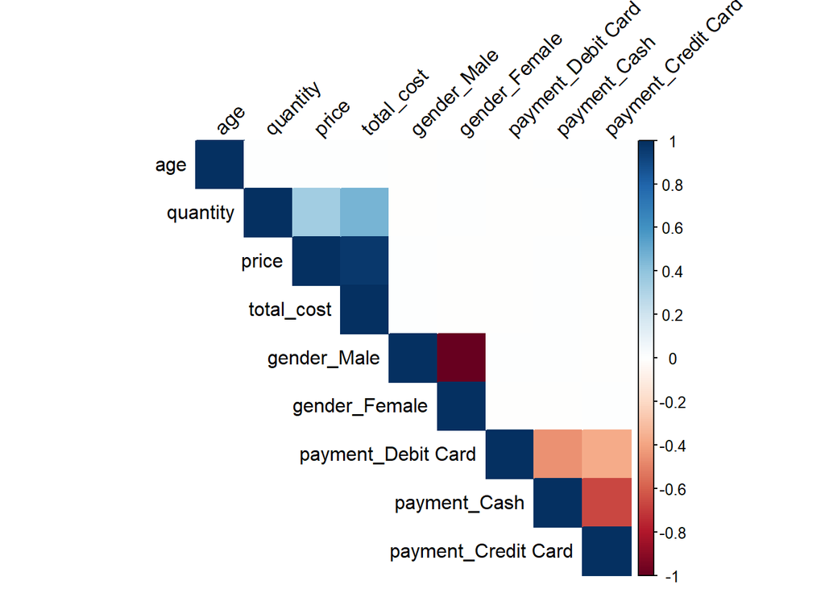

```r
# Load the corrplot library
library(corrplot)

correlation_matrix <- cor(customer_data[ c("age", "quantity", "price", "total_cost","gender_Male","gender_Female","payment_Debit Card","payment_Cash","payment_Credit Card")])

# Create a correlation plot
corrplot(correlation_matrix, method = "color", type = "upper", tl.col = "black", tl.srt = 45)
```

# 5 SMART Questions Analysis and stastical testing

## 5.1 EDA using ggplot2: Box plot to compare total cost by gender

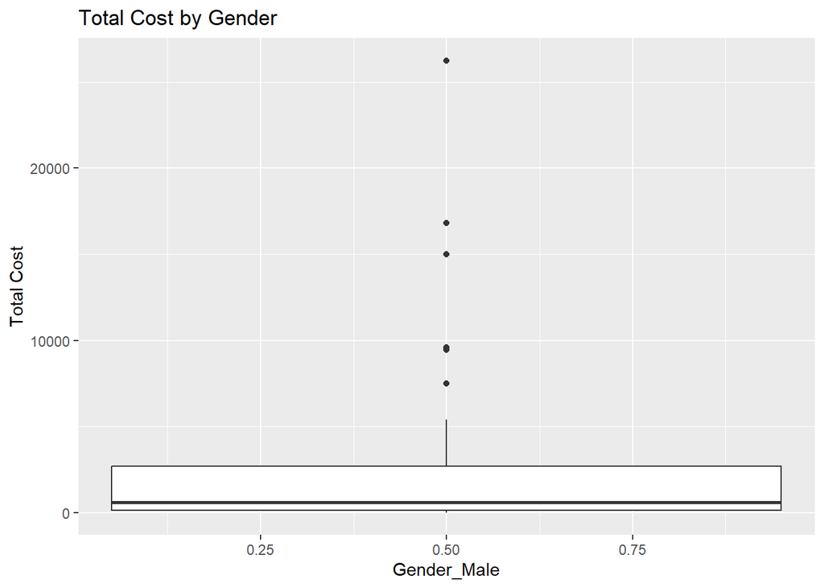

```r
library(ggplot2)
ggplot(data = customer_data, aes(x = gender_Male, y = total_cost, fill = gender_Male)) +
  geom_boxplot() +
  labs(title = "Total Cost by Gender", x = "Gender_Male", y = "Total Cost")
```

## 5.2 stastical testing for Gender and Total price

```r
t_test_gender <- t.test(total_cost ~ gender, data = customer_data)
# Check the p-value
if (t_test_gender$p.value < 0.05) {
  cat("Reject the null hypothesis. Gender has a significant effect on total purchase amount.\n")
} else {
  cat("Fail to reject the null hypothesis. Gender does not significantly affect total purchase amount.\n")
}
```

```
## Fail to reject the null hypothesis. Gender does not significantly affect total purchase amount.
```

```r
t_test_gender
```

```
##
##  Welch Two Sample t-test
##
## data:  total_cost by gender
## t = -0.3, df = 85875, p-value = 0.7
## alternative hypothesis: true difference in means between group Female and group Male is not equal to 0
## 95 percent confidence interval:
##  -62.3  44.7
## sample estimates:
## mean in group Female   mean in group Male
##                 2525                 2534
```

## 5.3 EDA using ggplot2: Scatter plot to examine the relationship between age and total cost

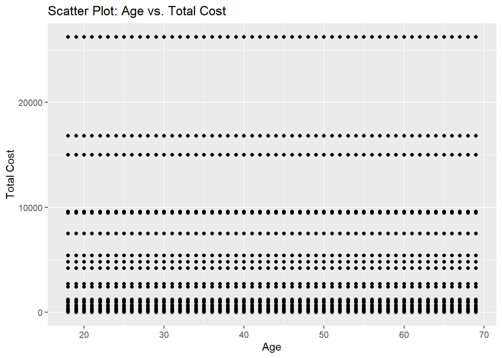

```r
ggplot(data = customer_data, aes(x = age, y = total_cost)) +
  geom_point() +
  labs(title = "Scatter Plot: Age vs. Total Cost", x = "Age", y = "Total Cost")
```

```r
correlation_age_cost <- cor(customer_data$age, customer_data$total_cost)
# Check the correlation coefficient
if (abs(correlation_age_cost) > 0.5) {
  cat("Accept the alternative hypothesis. There is a strong correlation between age and total purchase amount.\n")
} else {
  cat("Fail to accept the alternative hypothesis. There is no strong correlation between age and total purchase amount.\n")
}
```

```
## Fail to accept the alternative hypothesis. There is no strong correlation between age and total purchase amount.
```

## 5.4 EDA using ggplot2: Bar plot to compare total cost by Product category

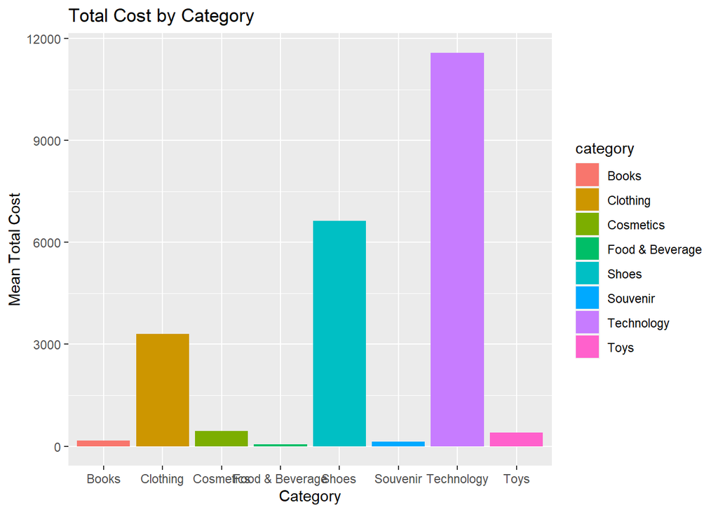

```r
ggplot(data = customer_data, aes(x = category, y = total_cost, fill = category)) +
  geom_bar(stat = "summary", fun = "mean") +
  labs(title = "Total Cost by Category", x = "Category", y = "Mean Total Cost")
```

```r
# Perform ANOVA test
anova_category <- aov(total_cost ~ category, data = customer_data)
#anova_category
# Check the p-value
p_value <- summary(anova_category)[[1]][[5]][1]
cat("pvalue is",p_value)
```

```
## pvalue is 0
```

```r
# Compare the p-value to the significance level (0.05)
if (p_value < 0.05) {


  cat("Reject the null hypothesis. Product categories have a significant effect on total purchase amount.\n")
} else {
  cat("Fail to reject the null hypothesis. Product categories do not significantly affect total purchase amount.\n")
}
```

```
## Reject the null hypothesis. Product categories have a significant effect on total purchase amount.
```

## 5.5 EDA using ggplot2: Box plot to compare total cost by payment method

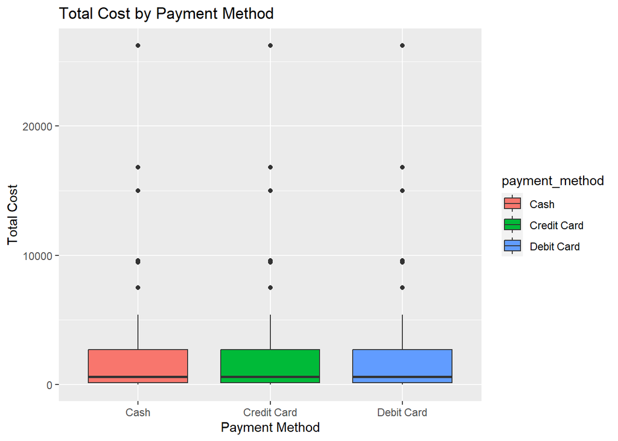

```r
ggplot(data = customer_data, aes(x = payment_method, y = total_cost, fill = payment_method)) +
  geom_boxplot() +
  labs(title = "Total Cost by Payment Method", x = "Payment Method", y = "Total Cost")
```

```r
# Perform ANOVA test
anova_payment <- aov(total_cost ~ payment_method, data = customer_data)

# Check the summary of the ANOVA
summary_anova_payment <- summary(anova_payment)

# Print the summary
print(summary_anova_payment)
```

```
##                   Df   Sum Sq  Mean Sq F value Pr(>F)
## payment_method     2 7.73e+06  3867327    0.22   0.81
## Residuals      99454 1.77e+12 17829582
```

```r
# Check the p-value
p_value_payment <- summary_anova_payment$"Pr(>F)"[1]

# Compare the p-value to the significance level (0.05)
if (!is.null(p_value_payment) && p_value_payment < 0.05) {
  cat("Reject the null hypothesis. Payment method has a significant effect on total purchase amount.\n")
} else  {
  cat("Fail to reject the null hypothesis. Payment method does not significantly affect total purchase amount.\n")
}
```

```
## Fail to reject the null hypothesis. Payment method does not significantly affect total purchase amount.
```

# 6 Fearture Engineering for age_group

```r
library("dplyr")
library("magrittr")
customer_data <- customer_data %>% mutate(invoice_date = as.Date(invoice_date,'%d/%m/%Y'))
customer_data <- customer_data %>% mutate(total_cost = price*quantity)
customer_data <- customer_data %>% mutate(age_group = ifelse(age < 20, "10's",
                              ifelse(age < 30, "20's",
                              ifelse(age < 40, "30's",
                              ifelse(age < 50, "40's",
                              ifelse(age < 60, "50's", "60's")))))) %>%
  dplyr::select(shopping_mall, invoice_date, invoice_no, customer_id, gender, age, age_group, category, quantity, price, total_cost,
         payment_method)
head(customer_data)
```

```
##    shopping_mall invoice_date invoice_no customer_id gender age age_group
## 1         Kanyon   2022-08-05    I138884     C241288 Female  28      20's
## 2 Forum Istanbul   2021-12-12    I317333     C111565   Male  21      20's
## 3      Metrocity   2021-11-09    I127801     C266599   Male  20      20's
## 4   Metropol AVM   2021-05-16    I173702     C988172 Female  66      60's
## 5         Kanyon   2021-10-24    I337046     C189076 Female  53      50's
## 6 Forum Istanbul   2022-05-24    I227836     C657758 Female  28      20's
##   category quantity  price total_cost payment_method
## 1 Clothing        5 1500.4       7502    Credit Card
## 2    Shoes        3 1800.5       5402     Debit Card
## 3 Clothing        1  300.1        300           Cash
## 4    Shoes        5 3000.8      15004    Credit Card
## 5    Books        4   60.6        242           Cash
## 6 Clothing        5 1500.4       7502    Credit Card
```

# 7 Model Building

## 7.1.1 Is there any corelation between customer’s age gender effect on shopping behaviour.

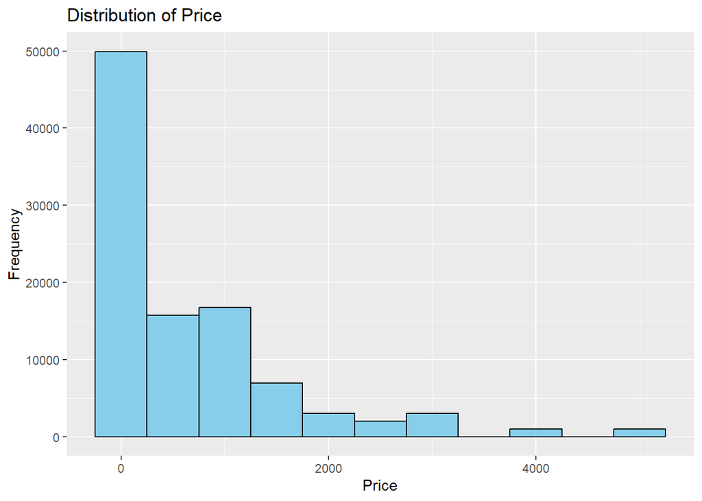

```r
ggplot(customer_data, aes(x = price)) +
  geom_histogram(binwidth = 500, fill = "skyblue", color = "black") +
  ggtitle("Distribution of Price") +
  xlab("Price") +
  ylab("Frequency")
```

## 7.1.2 Linear Model for the dependent variable Total_cost and independent variables

```r
model1 <- lm(total_cost ~ age + gender, data = customer_data)
summary(model1)
```

```
##
## Call:
## lm(formula = total_cost ~ age + gender, data = customer_data)
##
## Residuals:
##    Min     1Q Median     3Q    Max
##  -2549  -2393  -1929    186  23744
##
## Coefficients:
##             Estimate Std. Error t value Pr(>|t|)
## (Intercept) 2491.798     42.499   58.63   <2e-16 ***
## age            0.770      0.893    0.86     0.39
## genderMale     8.847     27.309    0.32     0.75
## ---
## Signif. codes:  0 '***' 0.001 '**' 0.01 '*' 0.05 '.' 0.1 ' ' 1
##
## Residual standard error: 4220 on 99454 degrees of freedom
## Multiple R-squared:  8.51e-06,   Adjusted R-squared:  -1.16e-05
## F-statistic: 0.423 on 2 and 99454 DF,  p-value: 0.655
```

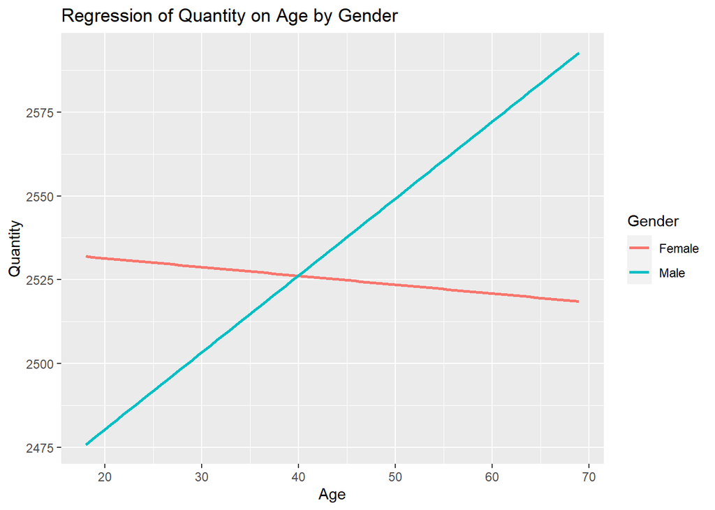

```r
ggplot(data = customer_data, aes(x = age, y = total_cost, color = gender)) +
  geom_smooth(method = "lm", se = FALSE) +  # Add a linear regression line
  labs(x = "Age", y = "Quantity", title = "Regression of Quantity on Age by Gender") + guides(color = guide_legend(title = "Gender"))
```

## 7.1.3 General analysis on gender vs age

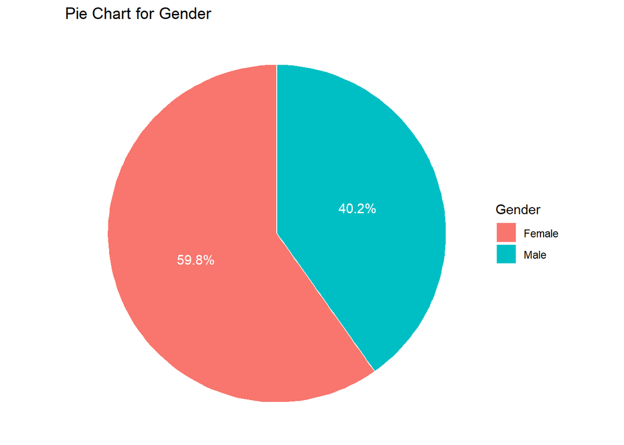

```r
frequency_table1 <- customer_data %>%
  count(gender) %>%
  mutate(percentage = n / sum(n) * 100)

ggplot(frequency_table1, aes(x = "", y = percentage, fill = gender)) +
  geom_bar(stat = "identity", width = 1, color = "white") +
  coord_polar("y", start = 0) +
  geom_text(aes(label = paste0(round(percentage, 1), "%")), position = position_stack(vjust = 0.5), color = "white") +
  ggtitle("Pie Chart for Gender") + labs(fill= "Gender") +
  theme_void()
```

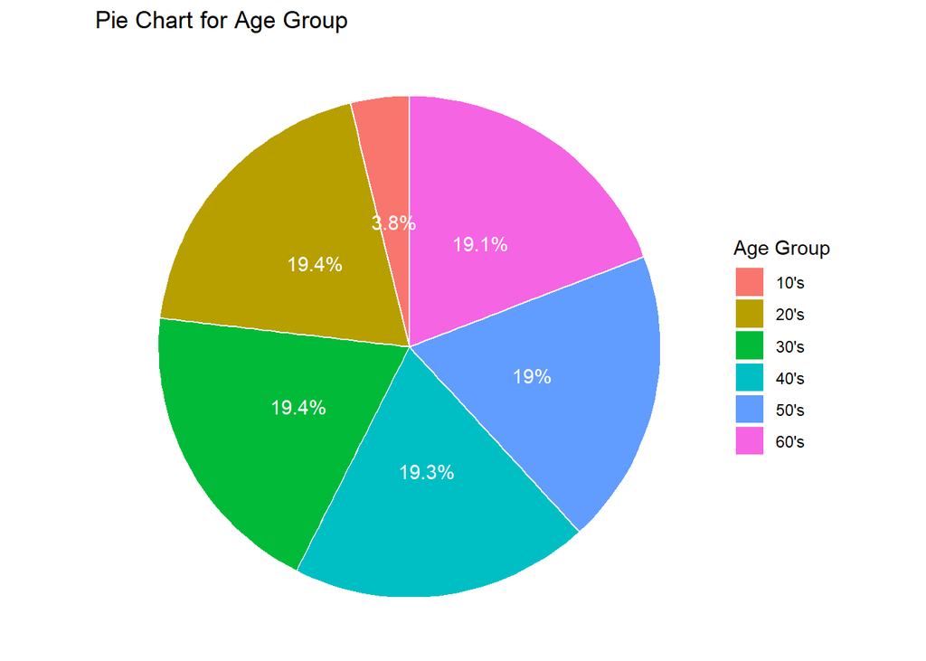

```r
frequency_table2 <- customer_data %>%
  count(age_group) %>%
  mutate(percentage = n / sum(n) * 100)

ggplot(frequency_table2, aes(x = "", y = percentage, fill = age_group)) +
  geom_bar(stat = "identity", width = 1, color = "white") +
  coord_polar("y", start = 0) +
  geom_text(aes(label = paste0(round(percentage, 1), "%")), position = position_stack(vjust = 0.5), color = "white") +
  ggtitle("Pie Chart for Age Group") + labs(fill= "Age Group") +
  theme_void()
```

## 7.1.4 Linera model for the Age and Gender Impact Shopping Behavior with the Quantity

```r
model2 <- lm(quantity ~ age + gender, data = customer_data)
summary(model2)
```

```
##
## Call:
## lm(formula = quantity ~ age + gender, data = customer_data)
##
## Residuals:
##     Min      1Q  Median      3Q     Max
## -2.0052 -1.0042 -0.0034  0.9974  1.9984
##
## Coefficients:
##              Estimate Std. Error t value Pr(>|t|)
## (Intercept)  3.00e+00   1.42e-02  211.00   <2e-16 ***
## age          6.28e-05   2.99e-04    0.21     0.83
## genderMale  -3.75e-04   9.14e-03   -0.04     0.97
## ---
## Signif. codes:  0 '***' 0.001 '**' 0.01 '*' 0.05 '.' 0.1 ' ' 1
##
## Residual standard error: 1.41 on 99454 degrees of freedom
## Multiple R-squared:  4.61e-07,   Adjusted R-squared:  -1.96e-05
## F-statistic: 0.0229 on 2 and 99454 DF,  p-value: 0.977
```

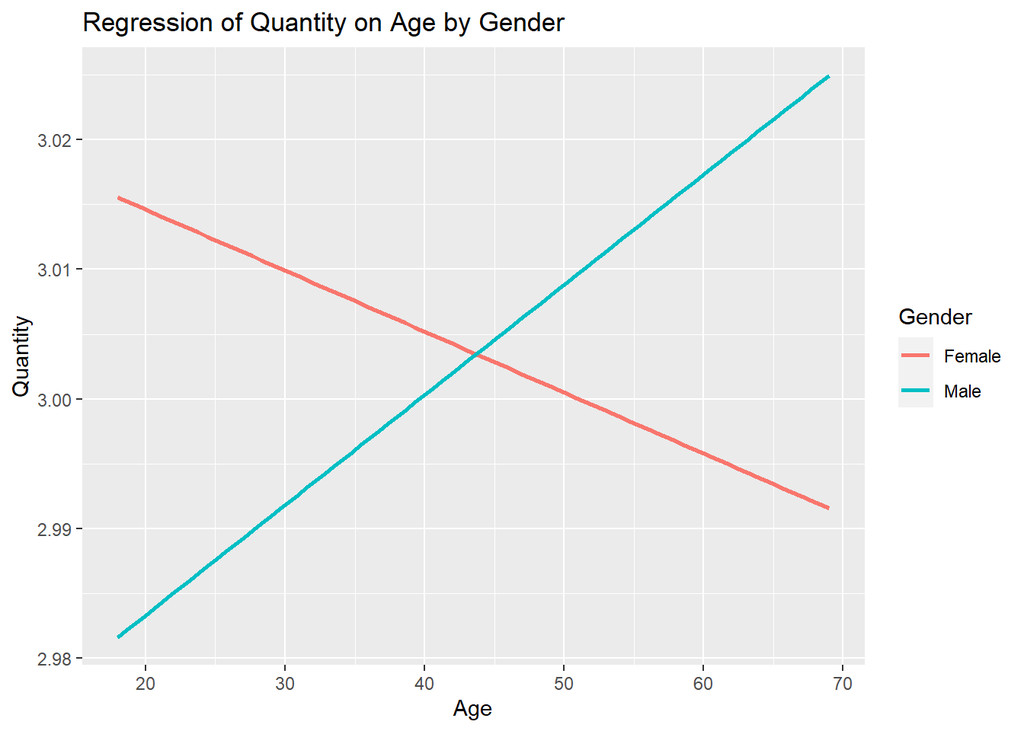

```r
ggplot(data = customer_data, aes(x = age, y = quantity, color = gender)) +
  geom_smooth(method = "lm", se = FALSE) +  # Add a linear regression line
  labs(x = "Age", y = "Quantity", title = "Regression of Quantity on Age by Gender") + guides(color = guide_legend(title = "Gender"))
```

## 7.2 Does the total purchase amount effect the total payment method?

### 7.2.1 consumption by payment method and by age group

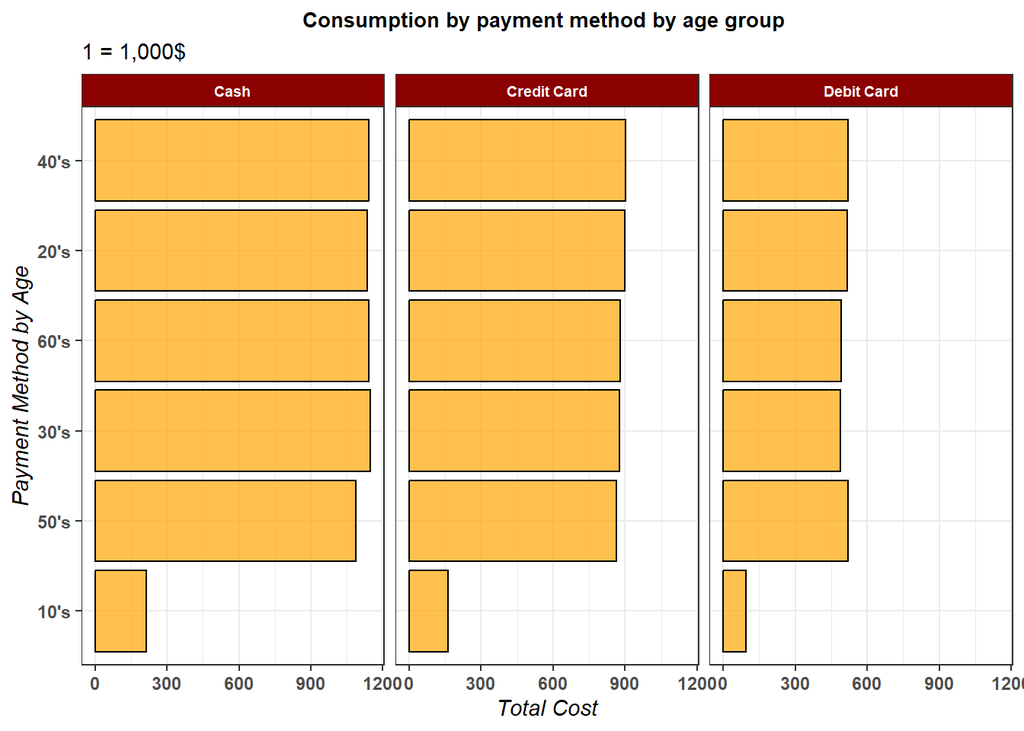

```r
payment_vector <- customer_data%>% group_by(payment_method, age_group) %>% summarise(customer = n(),sales_USD = sum(total_cost*0.052/1000), .groups = "drop") %>% arrange(sales_USD %>% desc())
payment_vector %>%
  ggplot(aes(reorder(age_group, sales_USD), sales_USD)) +
  geom_col(position = 'dodge', fill = 'orange', col = 'black', alpha = .7) +
  coord_flip() +
  facet_wrap(~ payment_method) +
  labs(title = 'Consumption by payment method by age group ',
       subtitle = '1 = 1,000$') +
  ylab('Total Cost') +
  xlab('Payment Method by Age') +
  theme_bw() +
  theme(plot.title = element_text(face = 'bold', size = 10, hjust = .5),
        axis.title.y = element_text(face = 'italic'),
        axis.title.x = element_text(face = 'italic'),
        axis.text.x = element_text(face = 'bold'),
        axis.text.y = element_text(face = 'bold'),
        strip.text.x = element_text(face = 'bold' , color = 'white', size = 7),
        strip.background.x = element_rect(fill = 'darkred'))
```

### 7.2.2 Linear model for price vs the paymentr method

```r
model3 <- lm(price ~ payment_method, data = customer_data)
summary(model3)
```

```
##
## Call:
## lm(formula = price ~ payment_method, data = customer_data)
##
## Residuals:
##    Min     1Q Median     3Q    Max
##   -686   -645   -484    509   4563
##
## Coefficients:
##                           Estimate Std. Error t value Pr(>|t|)
## (Intercept)                 690.82       4.46  154.74   <2e-16 ***
## payment_methodCredit Card    -2.28       6.73   -0.34     0.73
## payment_methodDebit Card     -3.79       8.00   -0.47     0.64
## ---
## Signif. codes:  0 '***' 0.001 '**' 0.01 '*' 0.05 '.' 0.1 ' ' 1
##
## Residual standard error: 941 on 99454 degrees of freedom
## Multiple R-squared:  2.57e-06,   Adjusted R-squared:  -1.75e-05
## F-statistic: 0.128 on 2 and 99454 DF,  p-value: 0.88
```

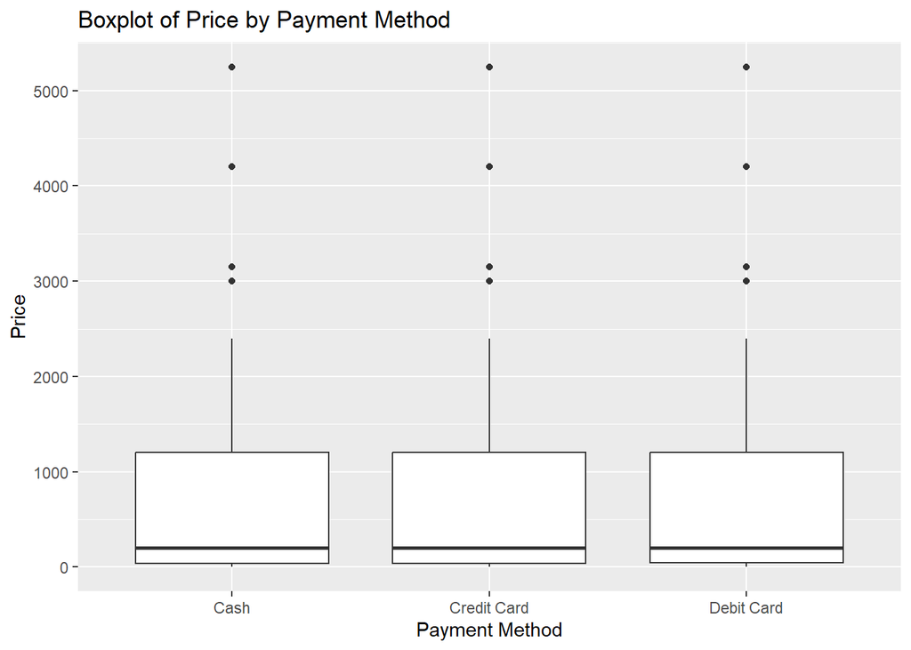

```r
ggplot(data = customer_data, aes(x = payment_method, y = price)) +
  geom_boxplot() +
  labs(x = "Payment Method", y = "Price", title = "Boxplot of Price by Payment Method")
```

## 7.3 Does the shopping mall location effect the purchase frequency?

### 7.3.1 Quantity and shopping mall Analysis

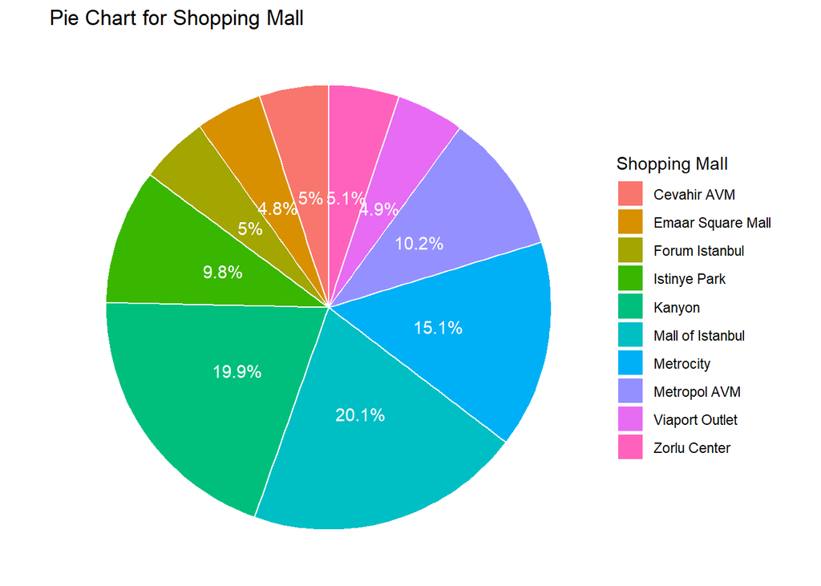

```r
frequency_table4 <- customer_data %>%
  count(shopping_mall) %>%
  mutate(percentage = n / sum(n) * 100)

ggplot(frequency_table4, aes(x = "", y = percentage, fill = shopping_mall)) +
  geom_bar(stat = "identity", width = 1, color = "white") +
  coord_polar("y", start = 0) +
  geom_text(aes(label = paste0(round(percentage, 1), "%")), position = position_stack(vjust = 0.5), color = "white") +
  ggtitle("Pie Chart for Shopping Mall") + labs(fill= "Shopping Mall") +  theme_void()
```

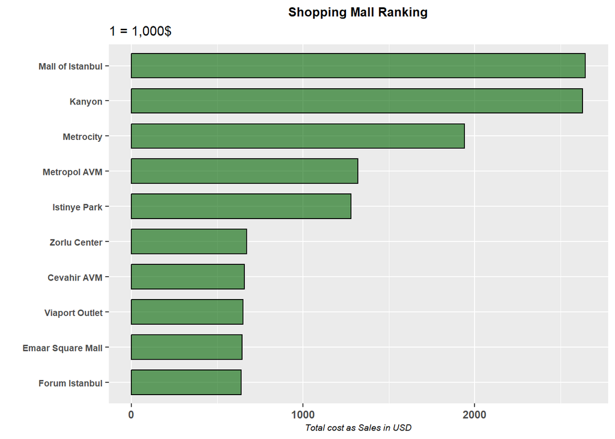

```r
mall_vector <- customer_data %>% group_by(shopping_mall) %>% summarise(customer = n(), sales_USD = sum(total_cost*0.052/1000), .groups = "drop") %>% arrange(sales_USD %>% desc())
mall_vector %>%
  ggplot() +
  geom_col(aes(reorder(shopping_mall, sales_USD), sales_USD),
           fill = 'darkgreen', col = 'black', alpha = .6,width = .7) +
  coord_flip() +
  labs(title = 'Shopping Mall Ranking', subtitle = '1 = 1,000$') + ylab('Total cost as Sales in USD') +
  xlab('') +
  theme(plot.title = element_text(size = 10, face = 'bold', hjust = .5),
        axis.title.y = element_text(face = 'bold'),
        axis.text.y = element_text(face = 'bold', size = 7),
        axis.title.x = element_text(face = 'italic', size = 7),
        axis.text.x = element_text(face = 'bold'))
```

### 7.3.2 Linear model for quantity and shopping mall

```r
model4 <- lm(quantity ~ shopping_mall, data = customer_data)
summary(model4)
```

```
##
## Call:
## lm(formula = quantity ~ shopping_mall, data = customer_data)
##
## Residuals:
##     Min      1Q  Median      3Q     Max
## -2.0143 -1.0125 -0.0018  1.0048  2.0093
##
## Coefficients:
##                                 Estimate Std. Error t value Pr(>|t|)
## (Intercept)                     2.995191   0.020002  149.75   <2e-16 ***
## shopping_mallEmaar Square Mall  0.018943   0.028550    0.66     0.51
## shopping_mallForum Istanbul     0.007032   0.028350    0.25     0.80
## shopping_mallIstinye Park       0.017282   0.024581    0.70     0.48
## shopping_mallKanyon             0.004203   0.022379    0.19     0.85
## shopping_mallMall of Istanbul   0.019099   0.022365    0.85     0.39
## shopping_mallMetrocity         -0.004451   0.023089   -0.19     0.85
## shopping_mallMetropol AVM       0.009434   0.024425    0.39     0.70
## shopping_mallViaport Outlet    -0.000482   0.028397   -0.02     0.99
## shopping_mallZorlu Center       0.006582   0.028169    0.23     0.82
## ---
## Signif. codes:  0 '***' 0.001 '**' 0.01 '*' 0.05 '.' 0.1 ' ' 1
##
## Residual standard error: 1.41 on 99447 degrees of freedom
## Multiple R-squared:  3.62e-05,   Adjusted R-squared:  -5.43e-05
## F-statistic:  0.4 on 9 and 99447 DF,  p-value: 0.936
```

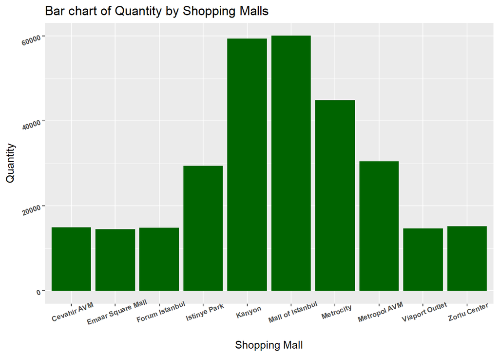

```r
ggplot() +
  geom_col(data = customer_data, aes(x = shopping_mall, y = quantity), fill = 'darkgreen') +
  labs(x = "Shopping Mall", y = "Quantity", title = "Bar chart of Quantity by Shopping Malls") +
  theme(axis.text = element_text(face = 'bold', size = 7, angle = 20))
```

## 7.4 Relation between the certain category and the total purchase amount?

### 7.4.1 Histogram for Age and Categories

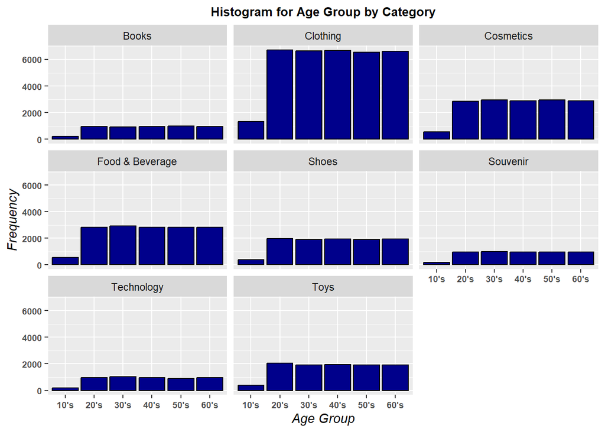

```r
customer_data %>% ggplot(data = customer_data, mapping = aes(x = age_group)) +
  geom_histogram(binwidth = 5, fill = 'darkblue', col = 'black', stat = "count") + facet_wrap(~ category) +
  xlab("Age Group") +
  ylab("Frequency") +
  ggtitle("Histogram for Age Group by Category") +
  theme(plot.title = element_text(face = 'bold', size = 10, hjust = .5),
        axis.title = element_text(face = 'italic'),
        axis.text = element_text(face = 'bold', size = 7, angle = 0))
```

### 7.4.2 Histogram for Gender and Categories

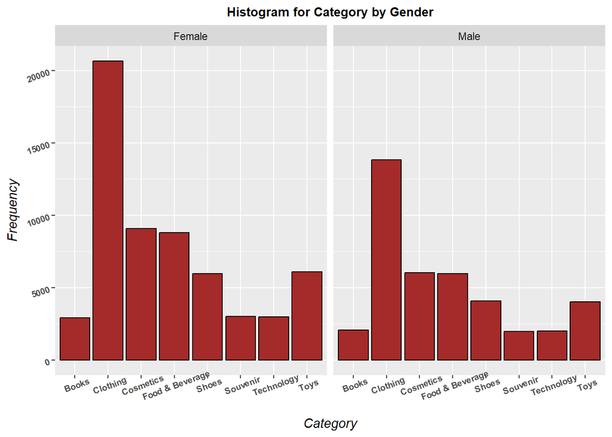

```r
customer_data %>% ggplot(data = customer_data, mapping = aes(x = category)) +
  geom_histogram(binwidth = 5, fill = 'brown', col = 'black', stat = "count") + facet_wrap(~ gender) +
  xlab("Category") +
  ylab("Frequency") +
  ggtitle("Histogram for Category by Gender") +
  theme(plot.title = element_text(face = 'bold', size = 10, hjust = .5),
        axis.title = element_text(face = 'italic'),
        axis.text = element_text(face = 'bold', size = 7, angle = 20))
```

### 7.4.3 Model for Category and total price

```r
model5 <- lm(price ~ category, data = customer_data)
summary(model5)
```

```
##
## Call:
## lm(formula = price ~ category, data = customer_data)
##
## Residuals:
##     Min      1Q  Median      3Q     Max
## -2106.9   -41.1    -0.5    40.2  2093.1
##
## Coefficients:
##                         Estimate Std. Error t value Pr(>|t|)
## (Intercept)                45.57       7.02    6.49  8.6e-11 ***
## categoryClothing          855.52       7.51  113.91  < 2e-16 ***
## categoryCosmetics          76.88       8.10    9.50  < 2e-16 ***
## categoryFood & Beverage   -29.90       8.12   -3.68  0.00023 ***
## categoryShoes            1761.82       8.59  205.14  < 2e-16 ***
## categorySouvenir          -10.67       9.92   -1.08  0.28191
## categoryTechnology       3111.37       9.92  313.60  < 2e-16 ***
## categoryToys               62.16       8.58    7.24  4.4e-13 ***
## ---
## Signif. codes:  0 '***' 0.001 '**' 0.01 '*' 0.05 '.' 0.1 ' ' 1
##
## Residual standard error: 495 on 99449 degrees of freedom
## Multiple R-squared:  0.723,  Adjusted R-squared:  0.723
## F-statistic: 3.71e+04 on 7 and 99449 DF,  p-value: <2e-16
```

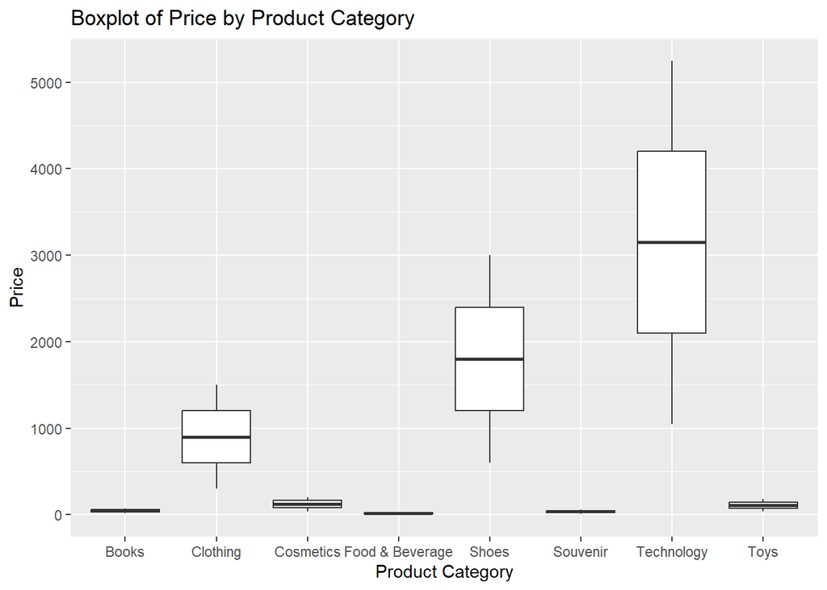

```r
ggplot(customer_data, aes(x = category, y = price)) +
  geom_boxplot() +
  labs(x = "Product Category", y = "Price") +
  ggtitle("Boxplot of Price by Product Category")
```

## 8 Conclusion

```r
#After a comprehensive analysis, it seems that Age and Gender don't greatly affect how much individuals spend on items, and product category significantly affects purchase amount, there's no apparent correlation between these criteria and the amount paid.
```